# Land Cover in Autauga WMA, AL

Lucas Parvin

19 January, 2024

# **Load Useful Packages**

```r
require(tidyverse)
require(sf)
require(tigris)
require(geodata)
require(ggplot2)
require(terra)
require(colorspace)
require(tidyterra)
require(ggnewscale)
require(cowplot)
require(ggspatial)
```

# **Load Spatial Data**

```r
# URL of the zipped shapefile on GitHub
url1 <- "https://github.com/lucasparvin/Spatial_Ecology/raw/main/Week_2_Lab/Assignment/AutaugaWMA.zip"

# Download the file
download.file(url1, destfile = "AutaugaWMA.zip", mode = "wb")

# Unzip the file
unzip("AutaugaWMA.zip", exdir = "AutaugaWMA")

# Load the shapefile
autauga_wma <- vect("AutaugaWMA/AutaugaWMA/AutaugaWMA.shp")



# URL of the zipped raster data on GitHub
url2 <- "https://github.com/lucasparvin/Spatial_Ecology/raw/main/Week_2_Lab/Assignment/autaugalc.zip"

# Download the file
download.file(url2, destfile = "autaugalc.zip", mode = "wb")

# Unzip the file
unzip("autaugalc.zip", exdir = "autaugalc")

# Load the raster data (adjust the path if needed)
landcover_raster <- rast("autaugalc/autaugalc")



# Load Alabama shape
alabama <- states() %>%
  filter(NAME == 'Alabama')

# Extract the CRS from the Alabama shape in WKT format
crs_alabama_wkt <- st_crs(alabama)$wkt
```

# **Make Sure Coordinate Systems are Aligned**

```r
# Transform Autauga WMA shapefile
crs_alabama <- crs(states() %>% filter(NAME == 'Alabama'))
autauga_wma_transformed <- terra::project(autauga_wma, crs_alabama)
autauga_wma_sf <- st_as_sf(autauga_wma_transformed)

# Transform landcover raster
landcover_raster_transformed <- project(landcover_raster, crs_alabama)
raster_df <- as.data.frame(landcover_raster_transformed, xy = TRUE)
colnames(raster_df) <- c("x", "y", "value")

# Load Alabama shape as sf object
alabama_sf <- states() %>%
  filter(NAME == 'Alabama') %>%
  st_as_sf()
```

# **Adding Extent Rectangle**

```r
# Calculate the bounding box (extent) of autauga_wma_sf
wma_bbox <- st_bbox(autauga_wma_sf)
```

# **Reclassifying Raster Values**

```r
# Landcover values
landcover_values <- c(11, 21, 22, 23, 31, 41, 42, 43, 52, 72, 81, 82, 90, 95)

# Corresponding colors
landcover_colors <- c("11" = "blue", "21" = "pink", "22" = "red", "23" = "red",
                      "31" = "brown", "41" = "lightgreen", "42" = "darkgreen",
                      "43" = "green", "52" = "tan", "72" = "yellow",
                      "81" = "orange", "82" = "brown", "90" = "lightblue",
                      "95" = "purple")

# Landcover labels
landcover_labels <- c("11" = "Open Water", "21" = "Developed Open, Open Space", "22" = "Developed, Low Intensity",
                      "23" = "Developed, Medium Intensity", "31" = "Barren Land", "41" = "Deciduous Forest",
                      "42" = "Evergreen Forest", "43" = "Mixed Forest", "52" = "Shrub/Scrub",
                      "72" = "Grassland/Herbaceous", "81" = "Pasture/Hay", "82" = "Crops",
                      "90" = "Woody Wetlands", "95" = "Emergent Herbaceous Wetlands")

raster_df <- as.data.frame(landcover_raster_transformed, xy = TRUE)
colnames(raster_df) <- c("x", "y", "landcover")
raster_df$landcover <- factor(raster_df$landcover, levels = landcover_values)
```

# **Zoomed in Map of Autauga WMA Land Cover**

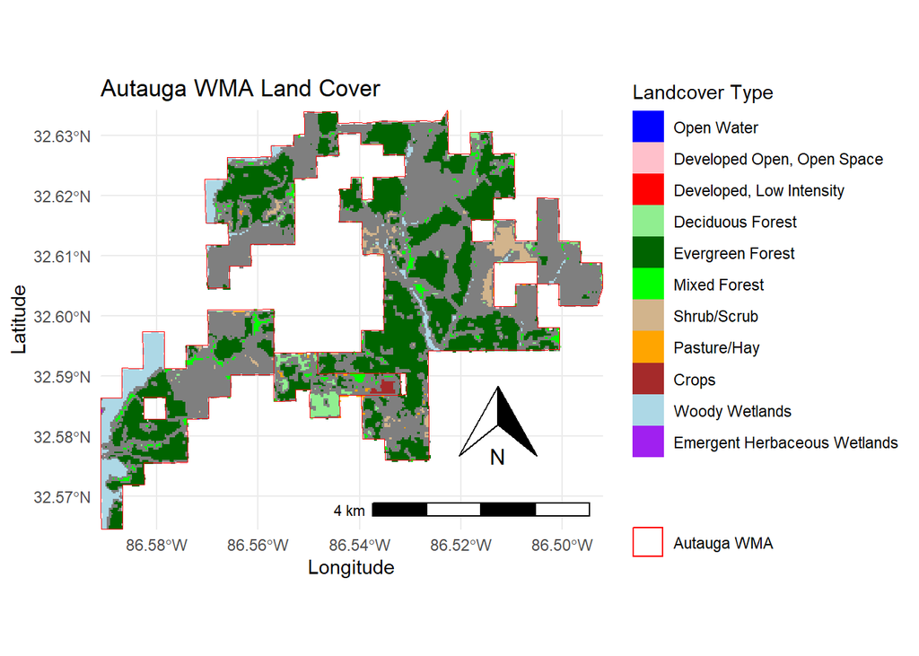

```r
ggplot(raster_df) +
  # Plot the raster
  geom_raster(aes(x = x, y = y, fill = landcover)) +
  scale_fill_manual(values = landcover_colors, labels = landcover_labels, name = "Landcover Type") +

  # Overlay Alabama shape
  geom_sf(data = alabama_sf, fill = NA, color = "black", size = 0.5) +

  # Overlay Autauga WMA with a named color for the legend
  geom_sf(data = autauga_wma_sf, fill = NA, color = "red", size = 0.5, aes(linetype = "Autauga WMA")) +

  # Set the name for the linetype legend
  scale_linetype_manual(values = "solid", labels = "Autauga WMA", name = "") +

  # Define plot labels and limits
  ggtitle("Autauga WMA Land Cover") +
  coord_sf(xlim = c(wma_bbox$xmin, wma_bbox$xmax), ylim = c(wma_bbox$ymin, wma_bbox$ymax), expand = FALSE) +

  # Customize the legend to combine land cover types and Autauga WMA boundary
  guides(fill = guide_legend(order = 1),
         linetype = guide_legend(order = 2)) +

  # Adjust plot theme
  theme_minimal() +
  theme(legend.position = "right") +

   # Add north arrow
  annotation_north_arrow(location = "br", which_north = "true", pad_x = unit(0.5, "in"), pad_y = unit(0.5, "in")) +

    # Set custom labels for axes
  labs(x = "Longitude", y = "Latitude") +

  # Add scale bar
  annotation_scale(location = "br", width_hint = 0.5)
```

The figure above demonstrates the land cover types within Alabama’s Autauga Wildlife Management Area (WMA), as defined by 2021 NLCD Data. Using these data, my lab mates and I can stratify point placement based on land cover types for future avian and vegetation surveys on Autauga WMA, one of the nine WMAs we seek to inventory bird and plant species. 2021 NLCD Data was acquired from the Multi-Resolution Land Characteristics Consortium.*Some of the land cover raster data was slightly distorted after I reclassified the coordinate system, causing a portion of the pixels to show up as gray. I tried remedying this by pulling Alabama and Autauga’s boundary into the same coordinate system as the raster, but other errors ensued.* The Autauga WMA Boundary was acquired from the USGS National Boundary Dataset. Alabama’s state boundary was brought into this environment using the following code: `alabama <- states() %>% filter(NAME == 'Alabama')`, and was include for a scale reference below.

# **Zoomed Out Map of Study Area Extent Within Alabama**

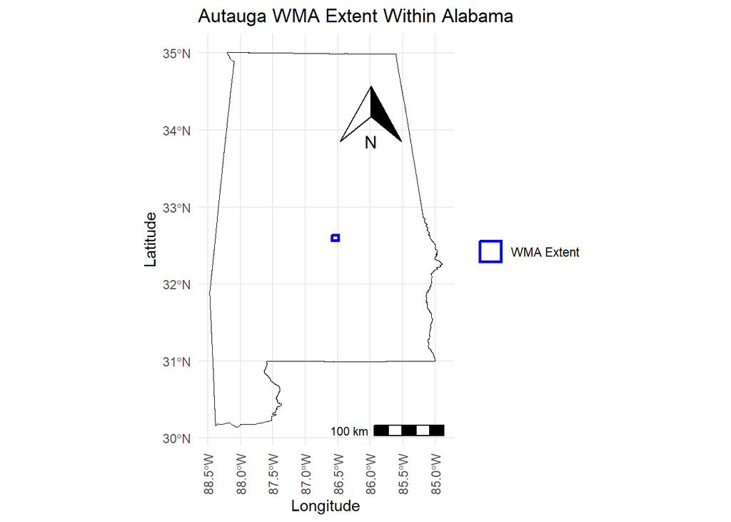

```r
ggplot() +
 # Overlay Alabama shape
  geom_sf(data = alabama_sf, fill = NA, color = "black", size = 0.5) +

  # Add an extent rectangle for Autauga WMA with a label for the legend
  geom_rect(aes(xmin = wma_bbox$xmin, xmax = wma_bbox$xmax,
                ymin = wma_bbox$ymin, ymax = wma_bbox$ymax, linetype = "WMA Extent"),
            color = "blue", fill = NA, linewidth = 1) +

    scale_linetype_manual(values = c("WMA Extent" = "solid"),
                        labels = c("WMA Extent"),
                        name = "") +

    # Define plot labels
  ggtitle("Autauga WMA Extent Within Alabama") +
  labs(x = "Longitude", y = "Latitude") +

  # Adjust plot theme
  theme_minimal() +
  theme(legend.position = "right",
        axis.text.x = element_text(angle = 90, vjust = 0.5, hjust = 1)) +
   # Add north arrow
  annotation_north_arrow(location = "tr", which_north = "true", pad_x = unit(0.5, "in"), pad_y = unit(0.5, "in")) +

  # Add scale bar
  annotation_scale(location = "br", width_hint = 0.5)
```

To understand the scale of the zoomed-in figure, this map shows the study area extent (blue line) within the state of Alabama (black border).The entirety of the Autauga WMA fits within the blue extent rectangle shown above.